# Exploration of the Relationship Between World GDP, Region, and Life Expectancy

Based on the Gapminder Dataset

Bob Palmer

March 24, 2019

## I. Description of the Data.

This report is based on the gapminder data file available from Gapminder.org. There are 41284 observations in the file, covering 197 unique countries. The data provides 6 variables: Country, Year, life (expectancy) , population, GDP income per capita, and region. The dispersion of the data varies; for most countries the years are given from 1800 to 2015, but for some for some countries the years are from 1970 to 2015.

Because for many countries population is given only once every ten years (presumably a decennial cencus) we have interpolated the missing values from the previous cencus until the next cencus occurs. We can also see that there were 2341 missing values in the income column; those missing income values area from 15 countries. We have interpolated the missing values with the mean of the income column.

Here is a sample of the dataset:

|  | Country | Year | life | population | income | region |
| --- | --- | --- | --- | --- | --- | --- |
| 1 | Afghanistan | 1800 | 28.21 | 3280000 | 603 | South Asia |
| 109 | Afghanistan | 1908 | 27.10 | 5021241 | 815 | South Asia |
| 216 | Afghanistan | 2015 | 57.63 | 32526562 | 1925 | South Asia |
| 433 | Algeria | 1800 | 28.82 | 2503218 | 716 | Middle East & North Africa |
| 541 | Algeria | 1908 | 27.84 | 4946166 | 1908 | Middle East & North Africa |
| 648 | Algeria | 2015 | 76.50 | 39666519 | 13434 | Middle East & North Africa |
| 911 | Antigua and Barbuda | 1800 | 33.54 | 37000 | 757 | America |
| 1019 | Antigua and Barbuda | 1908 | 33.54 | 34925 | 1373 | America |
| 1126 | Antigua and Barbuda | 2015 | 75.20 | 91818 | 21049 | America |
| 4788 | Botswana | 1800 | 33.60 | 121000 | 397 | Sub-Saharan Africa |
| 4896 | Botswana | 1908 | 33.60 | 122551 | 609 | Sub-Saharan Africa |
| 5003 | Botswana | 2015 | 66.40 | 2262485 | 17196 | Sub-Saharan Africa |
| 13723 | Greece | 1800 | 36.60 | 2151155 | 1371 | Europe & Central Asia |
| 13831 | Greece | 1908 | 41.47 | 4882706 | 3353 | Europe & Central Asia |
| 13938 | Greece | 2015 | 79.80 | 10954617 | 25430 | Europe & Central Asia |

## II. Questions to Ask

Interesting questions that we can ask about this data set include:

1. Which region has the highest median life expectancy and which has the lowest?
2. Which region has the highest median per capita GDP income and which has the lowest?
3. How does life expectancy change over time for the regions?
4. How does income change over time for the regions?
5. Is income a predictor of life expectancy?
6. Is region a predictor of life expectancy?

## III. Exploration of the Data

An interesting statistic in the summary of the data is that the mean life expectancy for all humans in all countries in the world for all of the years sampled is 42.88 years.

Here is a histogram of the incomes for all countries for all years in the data set:

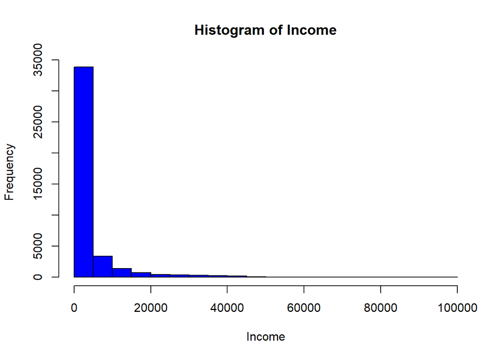

It seems clear from this that income per capita for all countries for all years in the data is definitely not in a gaussian (normal) distribution, but somewhat predictably it looks to be a Pareto distribution, showing the predominance of low incomes in a very large part of the population, and a long thin tail of high incomes. The largest bin of income is at or below 5,000 international dollars. This sharp fall-off of income still makes this hard to visualize, so let’s look at the frequency counts in a logarithmic transformation (in this case, log 2).

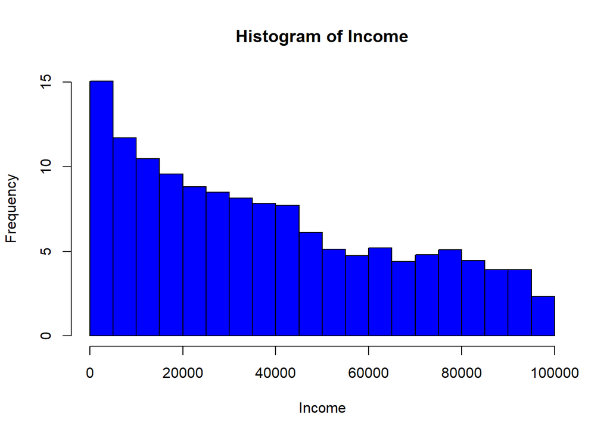

The fact that there are many more poor countries seems intuitive, but later we will see if that changes over the years of the study.

#### Question a) Which region has the highest median life expectancy and which has the lowest?

To answer this question, We explore the data graphically, by aggregating the median life expectancy for each region, and then showing the regions on a box chart. From this chart we can see that the Middle East & North Africa, South Asia and Sub-Saharan Africa regions all have a median life expectancy in the mid 32 years. Europe & Central Asia region has the highest median life expectancy of roughly 41 and three quarter years. (The median values are labeled on the chart in red.) We see that the first quartile of life expectancy for Europe is actually higher than the median (second quartile) of all of the other regions – in other words the whole interquartile range of Europe is above the median of all the other regions.

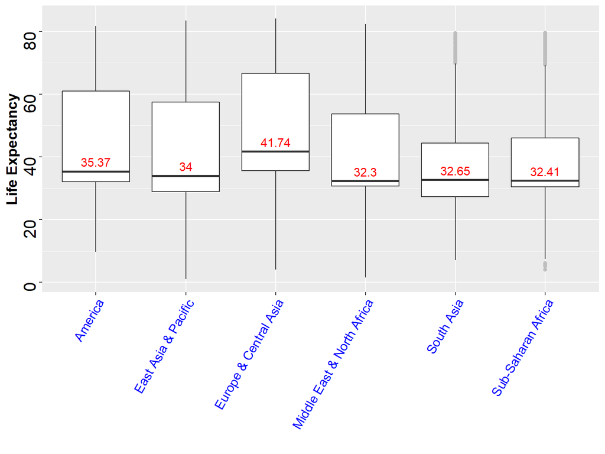

#### Question b) Which region has the highest median per capita GDP income and which has the lowest?

To answer this, We again build a boxplot by region, by aggregating the median income for each region, and again, the medians are labeled in red. (The extreme outliers in income have been removed for clarity, but the interquartile ranges were not affected by the method.)

We can see that Europe & Central Asia again is the leader with the highest median income. Sub-Saharan Africa is the lowest median income.

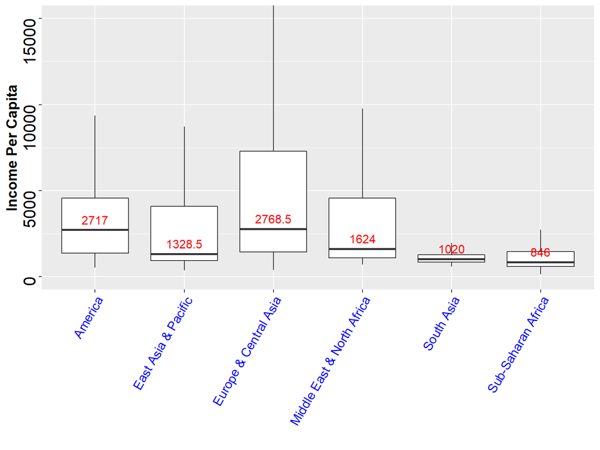

From the last two figures, we may hypothesize that there is a correlation between a region’s per capita income and life expectancy.

#### Question c) How does life expectancy change over time for the regions?

From the scatter plots below, we clearly see that beginning around the 1925-1950, all of the regions show a general trend of increasing life expectancy. We could hypothesize that this is due to increasing nutrition (perhaps driven by artificial nitrogen fertilizers introduced during that period) and increases in the efficacy of medical treatments.

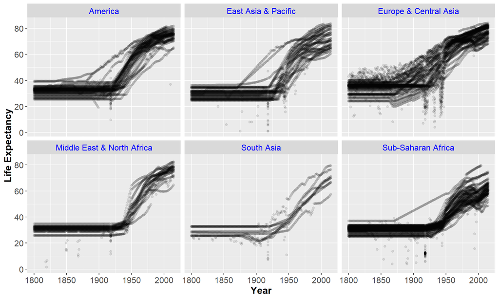

#### Question d) How does income change over time for the regions?

We can see some interesting changes; East Asia and the Pacific had some marked increases in income in the post WWII era (perhaps driven by the resergence in manufacturing in Asian countries). We can also see an explosion in income in the Middle East after the discovery and exploitation of petroleum that occurred in the post-war time period.

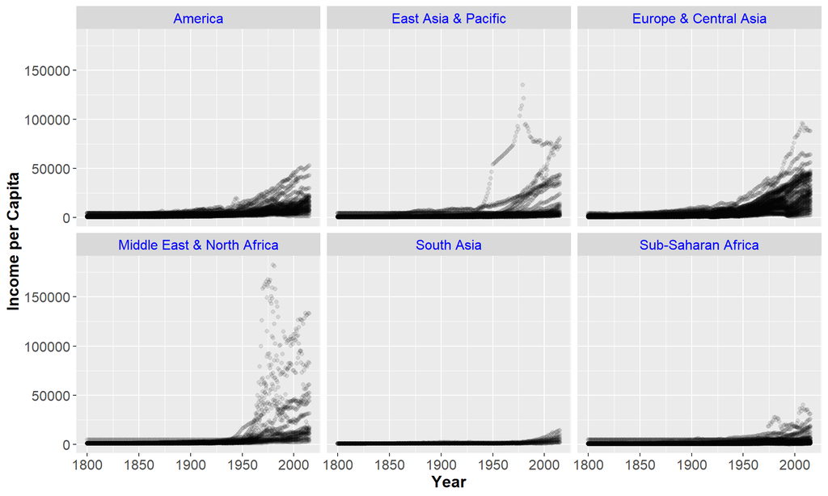

#### Question e) Is income a predictor of life expectancy?

#### Linear Regression Analysis

To examine question e) Is income a predictor of life expectancy?, let’s do a linear regression analysis on the data. Simple linear regression is a statistical method that allows us to summarize and study relationships between two quantitative variables; in this case the predictor variable (also known as independent variable) is income (x axis), and the response variable is life expectancy (y axis).

In figure below, we plot the raw data of income and life expectancy for the year 2000, and we add a linear model (regression) line.

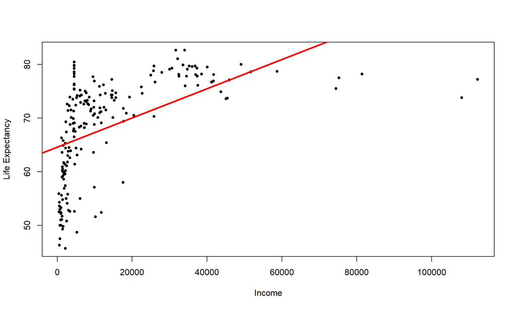

Here is the regression summary table:

```
##
## Call:
## lm(formula = life ~ income, data = income)
##
## Residuals:
##     Min      1Q  Median      3Q     Max
## -20.284  -4.910   2.115   5.889  14.622
##
## Coefficients:
##                Estimate  Std. Error t value             Pr(>|t|)
## (Intercept) 64.61078884  0.72332406  89.325 < 0.0000000000000002 ***
## income       0.00027278  0.00003155   8.645  0.00000000000000205 ***
## ---
## Signif. codes:  0 '***' 0.001 '**' 0.01 '*' 0.05 '.' 0.1 ' ' 1
##
## Residual standard error: 8 on 193 degrees of freedom
## Multiple R-squared:  0.2791, Adjusted R-squared:  0.2754
## F-statistic: 74.74 on 1 and 193 DF,  p-value: 0.000000000000002052
```

Multiple R-squared tells us how much of the variablity of the data is expalined by our model. Theoretically, it is the ratio between regression sum of square and total sum of square. It tells us the percentage of the life expectancy variablity which is expalined by the model.

From just looking at the the slope of the regression line above we might guess that there is a linear relationship between income and life expectancy, but lets further check if our linear model is valid. We can make a plot of the residuals vs. predicted values.

Let’s look at the distrbution of our residual errors to see if they appear to be in a normal distribution, which would indicate that our model is a good predictor of values for our data.

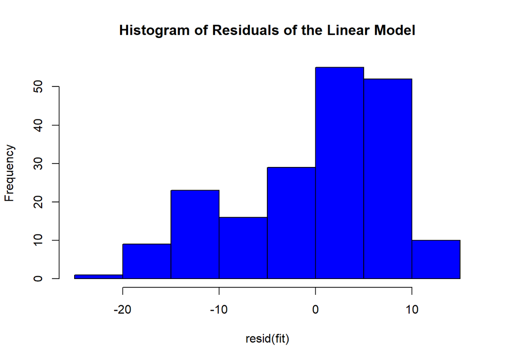

Well, the histogram above certainly does not appear to show us a normal distribution.

A normal Quantile-Quantile plot is another way to tell us whether our errors are in a normal distribution. If they are the plot would follow the line closely. (see below, upper right chart) Since it does not, we can infer that the residuals are not in a normal distribution, indicating that our model is not very appropriate.

A Scale-Location Chart (see below, lower left chart) also known as a Spread-Location plot shows us whether residuals are spread equally along the ranges of predictors, in order to check the assumption of equal variance (homoscedasticity). It’s good if you see a horizontal line with equally (randomly) spread points. That is clearly not the case here.

The Residuals vs. Leverage plot (bottom right, below) helps us identify influential data points (like outliers) in our model. The points we’re looking for(or not looking for) are values in the upper right or lower right corners, which are outside the red dashed Cook’s distance line. These are points that would be influential in the model and removing them would likely alter the regression results.

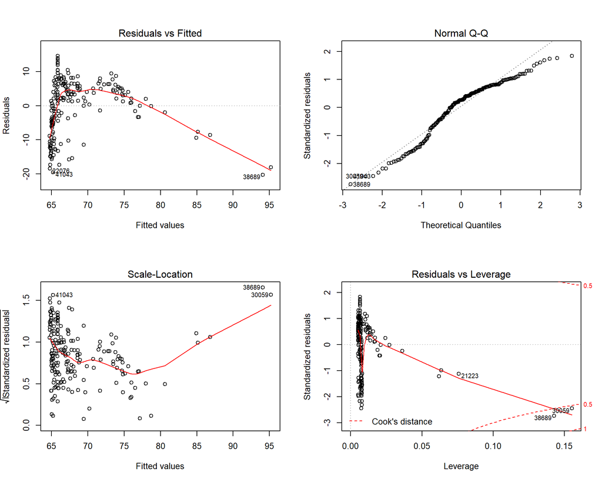

#### Question f) Is region a predictor of life expectancy?

If region is a predictor of life expectancy, then we could assume that a cluster analysis of the metrics (population, income, life expectancy) of each country would group them in clusters that are similar to their geograpic regions.

### Cluster Analysis

Cluster Analysis is a form of exploratory data analysis (EDA) where observations are divided into meaningful groups that share common characteristics (features).

In order to decide how many clusters to use in our analysis, we can use a so-called elbow chart, which measures the distances differentiating the members of the clusters for different numbers of clusters.

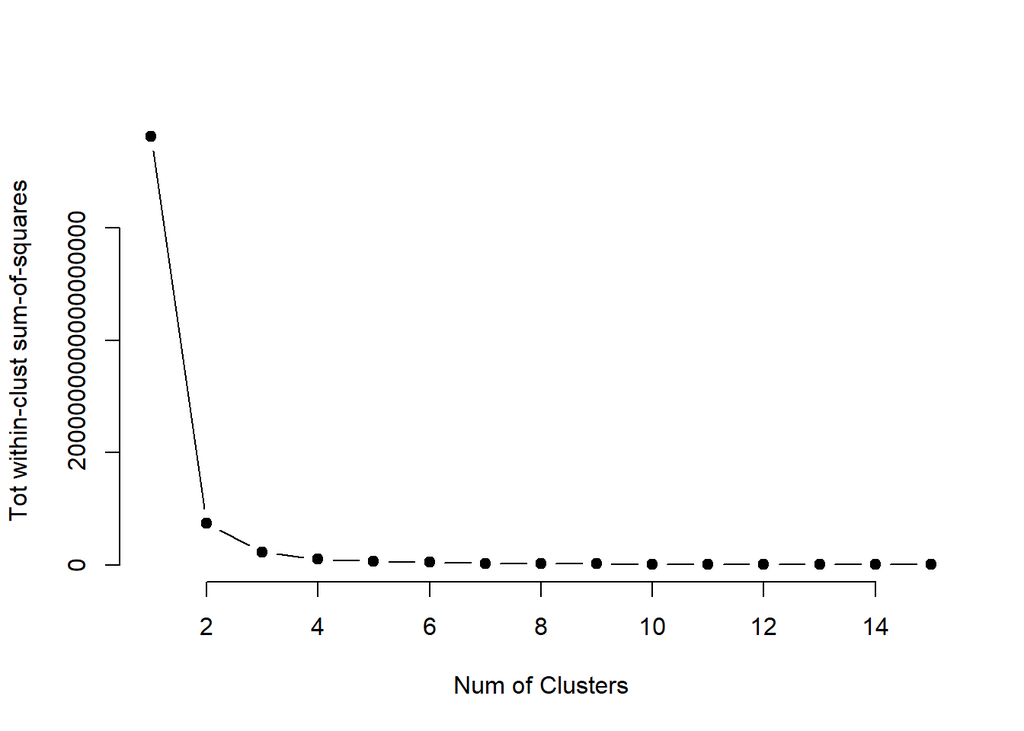

We see that three is a good “elbow point” for selecting the number of clusters to use in our analysis.

However, in the figure below, we see that two outlier countries, India and China are in their own cluster alone. This could be because India and china have an order of magnitude higher population than all other countries in the data set.

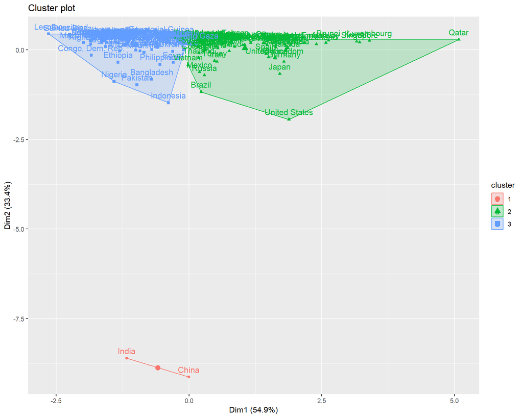

So let’s see the clusters without the two outlier countries:

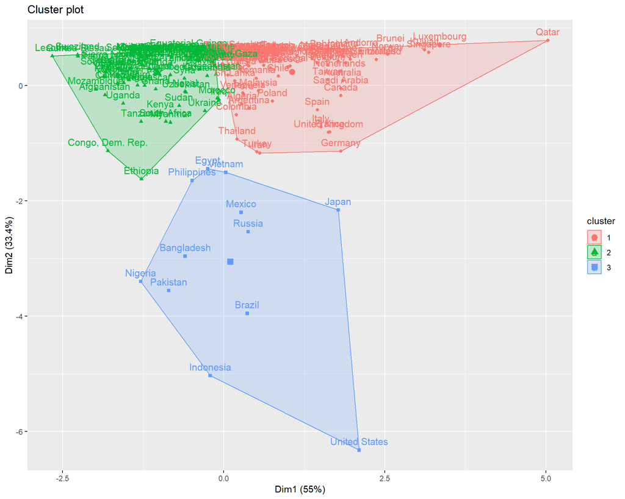

We see that the countries are clustered in such a way that they do not reflect their geographic regions in the clusters. This would not give us enough evidence to support the hypothesis that region is determinitive of life expectancy.

## IV. Findings

To review, here are the six questions we sought to answer with this report.

a. Which region has the highest median life expectancy and which has the lowest?

Using the box plots, we discovered that Europe & Central Asia has the hightest median life expectancy, and Middle East & North Africa has the lowest.

b. Which region has the highest median per capita GDP income and which has the lowest?

We found that Europe & Central Asia has the hightest median income, and Sub-Saharan Africa has the lowest.

c. How does life expectancy change over time for the regions?

The faceted scatter plots for the regions indicated that ll of the regions show a general trend of increasing life expectancy. We could hypothesize that this is due to increasing nutrition (perhaps driven by artificial nitrogen fertilizers introduced during that period) and increases in the efficacy of medical treatments. Data could be found for those observations and that analysis could be the topic of future analysis.

d. How does income change over time for the regions?

All of the regions had increases in income over the years recorded. East Asia & Pacific had some marked increases in income in the post WWII era (perhaps driven by the resergence in manufacturing in Asian countries). We can also see an explosion in income in the Middle East after the discovery and exploitation of petroleum that occurred in the post-war time period. South Asia and Sub-Saharan Africa regionis did not indicate as large of an increase.

e. Is income a predictor of life expectancy?

Our linear regression analysis was not conclusive in showing that as income increased so did life expectancy.

f. Is region a predictor of life expectancy?

Our hypothesis was that if region where a predictor of life expectancy, then we could assume that a cluster analysis of the metrics (population, income, life expectancy) of each country would group them in clusters that are similar to their geograpic regions. But, this clustering was not upheld by the results. Therefore we do not have sufficient evidence from the data to say that region is determinative of life expectancy.